# 6-24-21 EDA assignment

Main Question: How have pollution levels changed over the course of the COVID-19 pandemic? Have the pandemic lockdown policies affected these pollution levels? pollution levels = AQI (Air Quality Index) measurements by EPA planning on using COVID-19 fatalities as a proxy for the lockdown policies

hypothesis: as lockdown policies become more strict (proxy: as COVID deaths increase), pollution levels (AQI measurements) will decrease

loading needed packages

```r
library(tidyverse)
library(fs)
```

loading in first dataset I’ll be using (EPA data from 2020)

```r
EPA_2020 <- read_csv(path("EPA AQI by county 2020.csv"))
```

getting an idea of what the dataset looks like

```r
glimpse(EPA_2020)
```

```
Rows: 336,701
Columns: 10
$ `State Name`                <chr> "Alabama", "Alabama", "Alabama", "Alabama", "Alabama…
$ `county Name`               <chr> "Baldwin", "Baldwin", "Baldwin", "Baldwin", "Baldwin…
$ `State Code`                <dbl> 1, 1, 1, 1, 1, 1, 1, 1, 1, 1, 1, 1, 1, 1, 1, 1, 1, 1…
$ `County Code`               <dbl> 3, 3, 3, 3, 3, 3, 3, 3, 3, 3, 3, 3, 3, 3, 3, 3, 3, 3…
$ Date                        <chr> "1/1/20", "1/4/20", "1/7/20", "1/10/20", "1/13/20", …
$ AQI                         <dbl> 48, 13, 14, 39, 29, 15, 10, 38, 17, 20, 30, 16, 21, …
$ Category                    <chr> "Good", "Good", "Good", "Good", "Good", "Good", "Goo…
$ `Defining Parameter`        <chr> "PM2.5", "PM2.5", "PM2.5", "PM2.5", "PM2.5", "PM2.5"…
$ `Defining Site`             <chr> "01-003-0010", "01-003-0010", "01-003-0010", "01-003…
$ `Number of Sites Reporting` <dbl> 1, 1, 1, 1, 1, 1, 1, 1, 1, 1, 1, 1, 1, 1, 1, 1, 1, 1…
```

```r
library(skimr)
skim(EPA_2020)
```

```
── Data Summary ────────────────────────
                           Values
Name                       EPA_2020
Number of rows             336701
Number of columns          10
_______________________
Column type frequency:
  character                6
  numeric                  4
________________________
Group variables            None

── Variable type: character ──────────────────────────────────────────────────────────────
  skim_variable      n_missing complete_rate   min   max empty n_unique whitespace
1 State Name                 0             1     4    20     0       54          0
2 county Name                0             1     3    21     0      803          0
3 Date                       0             1     6     8     0      366          0
4 Category                   0             1     4    30     0        6          0
5 Defining Parameter         0             1     2     5     0        6          0
6 Defining Site              0             1    11    11     0     2112          0

── Variable type: numeric ────────────────────────────────────────────────────────────────
  skim_variable             n_missing complete_rate  mean    sd    p0   p25   p50   p75
1 State Code                        0             1 30.6  16.1      1    17    31    42
2 County Code                       0             1 82.0  91.8      1    25    59   109
3 AQI                               0             1 36.9  24.2      0    26    35    44
4 Number of Sites Reporting         0             1  2.04  2.43     1     1     1     2
   p100 hist
1    80 ▅▆▇▃▁
2   840 ▇▁▁▁▁
3  1928 ▇▁▁▁▁
4    34 ▇▁▁▁▁
```

cleaned up column names to all lowercase and joined words

```r
library(janitor)
EPA_2020 <- clean_names(EPA_2020)
view(EPA_2020)
```

filtered dataset to only include New York data

```r
only_nys_2020 <- filter(EPA_2020, state_name == "New York")
only_nys_2020
```

| state_name | county_name | state_code | county_code | date | aqi | category | defining_parameter | defining_site | number_of_sites_reporting |
| --- | --- | --- | --- | --- | --- | --- | --- | --- | --- |
| New York | Albany | 36 | 1 | 1/1/20 | 17 | Good | PM2.5 | 36-001-0005 | 2 |
| New York | Albany | 36 | 1 | 1/2/20 | 38 | Good | PM2.5 | 36-001-0005 | 2 |
| New York | Albany | 36 | 1 | 1/3/20 | 54 | Moderate | PM2.5 | 36-001-0005 | 2 |
| New York | Albany | 36 | 1 | 1/4/20 | 53 | Moderate | PM2.5 | 36-001-0005 | 2 |
| New York | Albany | 36 | 1 | 1/5/20 | 12 | Good | PM2.5 | 36-001-0005 | 2 |
| New York | Albany | 36 | 1 | 1/6/20 | 29 | Good | PM2.5 | 36-001-0005 | 2 |
| New York | Albany | 36 | 1 | 1/7/20 | 29 | Good | PM2.5 | 36-001-0005 | 2 |
| New York | Albany | 36 | 1 | 1/8/20 | 31 | Good | PM2.5 | 36-001-0005 | 2 |
| New York | Albany | 36 | 1 | 1/9/20 | 16 | Good | PM2.5 | 36-001-0005 | 2 |
| New York | Albany | 36 | 1 | 1/10/20 | 31 | Good | PM2.5 | 36-001-0005 | 2 |

[output cut: 990 more lines]

loading in second EPA dataset (what’s available for 2021 so far)

```r
EPA_2021 <- read_csv(path("EPA AQI by county 2021.csv"))
```

getting a look at second dataset

```r
glimpse(EPA_2021)
```

```
Rows: 40,518
Columns: 10
$ `State Name`                <chr> "Alabama", "Alabama", "Alabama", "Alabama", "Alabama…
$ `county Name`               <chr> "DeKalb", "DeKalb", "DeKalb", "DeKalb", "DeKalb", "D…
$ `State Code`                <dbl> 1, 1, 1, 1, 1, 1, 1, 1, 1, 1, 1, 1, 1, 1, 1, 1, 1, 1…
$ `County Code`               <dbl> 49, 49, 49, 49, 49, 49, 49, 49, 49, 49, 49, 49, 49, …
$ Date                        <chr> "1/1/21", "1/2/21", "1/3/21", "1/4/21", "1/5/21", "1…
$ AQI                         <dbl> 30, 27, 34, 36, 31, 27, 29, 22, 26, 25, 24, 21, 23, …
$ Category                    <chr> "Good", "Good", "Good", "Good", "Good", "Good", "Goo…
$ `Defining Parameter`        <chr> "Ozone", "Ozone", "Ozone", "Ozone", "Ozone", "Ozone"…
$ `Defining Site`             <chr> "01-049-9991", "01-049-9991", "01-049-9991", "01-049…
$ `Number of Sites Reporting` <dbl> 1, 1, 1, 1, 1, 1, 1, 1, 1, 1, 1, 1, 1, 1, 1, 1, 1, 1…
```

```r
view(EPA_2021)
```

cleaned up column names to all lowercase and joined words

```r
EPA_2021 <- clean_names(EPA_2021)
view(EPA_2021)
```

filtered second dataset to only include New York data

```r
only_nys_2021 <- filter(EPA_2021, state_name == "New York")
view(only_nys_2021)
```

getting important info about both NYS datasets

```r
skim(only_nys_2020)
```

```
── Data Summary ────────────────────────
                           Values
Name                       only_nys_2020
Number of rows             10092
Number of columns          10
_______________________
Column type frequency:
  character                6
  numeric                  4
________________________
Group variables            None

── Variable type: character ──────────────────────────────────────────────────────────────
  skim_variable      n_missing complete_rate   min   max empty n_unique whitespace
1 state_name                 0             1     8     8     0        1          0
2 county_name                0             1     4    12     0       28          0
3 date                       0             1     6     8     0      366          0
4 category                   0             1     4    30     0        4          0
5 defining_parameter         0             1     2     5     0        5          0
6 defining_site              0             1    11    11     0       50          0

── Variable type: numeric ────────────────────────────────────────────────────────────────
  skim_variable             n_missing complete_rate  mean     sd    p0   p25   p50   p75
1 state_code                        0             1 36     0        36    36    36    36
2 county_code                       0             1 64.5  32.0       1    41    65    87
3 aqi                               0             1 34.6  14.1       0    28    34    41
4 number_of_sites_reporting         0             1  1.65  0.918     1     1     1     2
   p100 hist
1    36 ▁▁▇▁▁
2   119 ▃▇▇▇▆
3   155 ▆▇▁▁▁
4     4 ▇▃▁▁▁
```

```r
skim(only_nys_2021)
```

```
── Data Summary ────────────────────────
                           Values
Name                       only_nys_2021
Number of rows             2477
Number of columns          10
_______________________
Column type frequency:
  character                6
  numeric                  4
________________________
Group variables            None

── Variable type: character ──────────────────────────────────────────────────────────────
  skim_variable      n_missing complete_rate   min   max empty n_unique whitespace
1 state_name                 0             1     8     8     0        1          0
2 county_name                0             1     4    12     0       28          0
3 date                       0             1     6     7     0       91          0
4 category                   0             1     4    30     0        3          0
5 defining_parameter         0             1     2     5     0        5          0
6 defining_site              0             1    11    11     0       49          0

── Variable type: numeric ────────────────────────────────────────────────────────────────
  skim_variable             n_missing complete_rate  mean     sd    p0   p25   p50   p75
1 state_code                        0             1 36     0        36    36    36    36
2 county_code                       0             1 64.3  32.0       1    41    65    87
3 aqi                               0             1 36.6  11.5       0    31    36    41
4 number_of_sites_reporting         0             1  1.66  0.927     1     1     1     2
   p100 hist
1    36 ▁▁▇▁▁
2   119 ▃▇▇▇▆
3   116 ▁▇▁▁▁
4     4 ▇▃▁▁▁
```

I think I’m going to look only at the Ozone and PM2.5 observations

The pollutants I originally wanted to look at (CO, SO2, and NO2) don’t have consistent readings in all the counties in the state in only_nys_2020 and only_nys_2021 datasets. There’s either a fair amount of readings but all in one county, or a handful of readings in a few counties. Using the search feature in the view window for each dataset, it looks like the ozone and the pm2.5 readings are taken consistently in every county in the state.

I think focusing on the ozone observations will still work for my purpose because bad ozone is created when pollution emitted by cars, factories, etc react chemically in sunlight, so if there’s ozone, there also has to be pollution. Ozone is bad for your health because it makes it hard to breathe (especially for those with asthma) and it can cause issues for vegetation leading to bigger ecosystem problems. More info can be found here: https://www.epa.gov/ground-level-ozone-pollution/ground-level-ozone-basics

I think including the PM2.5 readings will help round out my analysis because PM2.5 is extremely small particulate matter that is either emitted by construction sites, smokestacks, etc or created by chemical reactions between pollutants emitted by cars, factories, etc. PM2.5 causes issues because it can create hazes (think LA) reducing visibility. It can also be breathed in and can even get into your bloodstream. More info here: https://www.epa.gov/pm-pollution/particulate-matter-pm-basics

filtered the two datasets to include only Ozone and PM2.5 observations

```r
filter(only_nys_2020, defining_parameter == "Ozone" | defining_parameter == "PM2.5")
```

| state_name | county_name | state_code | county_code | date | aqi | category | defining_parameter | defining_site | number_of_sites_reporting |
| --- | --- | --- | --- | --- | --- | --- | --- | --- | --- |
| New York | Albany | 36 | 1 | 1/1/20 | 17 | Good | PM2.5 | 36-001-0005 | 2 |
| New York | Albany | 36 | 1 | 1/2/20 | 38 | Good | PM2.5 | 36-001-0005 | 2 |
| New York | Albany | 36 | 1 | 1/3/20 | 54 | Moderate | PM2.5 | 36-001-0005 | 2 |
| New York | Albany | 36 | 1 | 1/4/20 | 53 | Moderate | PM2.5 | 36-001-0005 | 2 |
| New York | Albany | 36 | 1 | 1/5/20 | 12 | Good | PM2.5 | 36-001-0005 | 2 |
| New York | Albany | 36 | 1 | 1/6/20 | 29 | Good | PM2.5 | 36-001-0005 | 2 |
| New York | Albany | 36 | 1 | 1/7/20 | 29 | Good | PM2.5 | 36-001-0005 | 2 |
| New York | Albany | 36 | 1 | 1/8/20 | 31 | Good | PM2.5 | 36-001-0005 | 2 |
| New York | Albany | 36 | 1 | 1/9/20 | 16 | Good | PM2.5 | 36-001-0005 | 2 |
| New York | Albany | 36 | 1 | 1/10/20 | 31 | Good | PM2.5 | 36-001-0005 | 2 |

[output cut: 990 more lines]

```r
only_nys_2020
```

| state_name | county_name | state_code | county_code | date | aqi | category | defining_parameter | defining_site | number_of_sites_reporting |
| --- | --- | --- | --- | --- | --- | --- | --- | --- | --- |
| New York | Albany | 36 | 1 | 1/1/20 | 17 | Good | PM2.5 | 36-001-0005 | 2 |
| New York | Albany | 36 | 1 | 1/2/20 | 38 | Good | PM2.5 | 36-001-0005 | 2 |
| New York | Albany | 36 | 1 | 1/3/20 | 54 | Moderate | PM2.5 | 36-001-0005 | 2 |
| New York | Albany | 36 | 1 | 1/4/20 | 53 | Moderate | PM2.5 | 36-001-0005 | 2 |
| New York | Albany | 36 | 1 | 1/5/20 | 12 | Good | PM2.5 | 36-001-0005 | 2 |
| New York | Albany | 36 | 1 | 1/6/20 | 29 | Good | PM2.5 | 36-001-0005 | 2 |
| New York | Albany | 36 | 1 | 1/7/20 | 29 | Good | PM2.5 | 36-001-0005 | 2 |
| New York | Albany | 36 | 1 | 1/8/20 | 31 | Good | PM2.5 | 36-001-0005 | 2 |
| New York | Albany | 36 | 1 | 1/9/20 | 16 | Good | PM2.5 | 36-001-0005 | 2 |
| New York | Albany | 36 | 1 | 1/10/20 | 31 | Good | PM2.5 | 36-001-0005 | 2 |

[output cut: 990 more lines]

```r
filter(only_nys_2021, defining_parameter == "Ozone" | defining_parameter == "PM2.5")
```

| state_name | county_name | state_code | county_code | date | aqi | category | defining_parameter | defining_site | number_of_sites_reporting |
| --- | --- | --- | --- | --- | --- | --- | --- | --- | --- |
| New York | Albany | 36 | 1 | 1/1/21 | 36 | Good | PM2.5 | 36-001-0005 | 2 |
| New York | Albany | 36 | 1 | 1/2/21 | 28 | Good | Ozone | 36-001-0012 | 2 |
| New York | Albany | 36 | 1 | 1/3/21 | 38 | Good | PM2.5 | 36-001-0005 | 2 |
| New York | Albany | 36 | 1 | 1/4/21 | 56 | Moderate | PM2.5 | 36-001-0005 | 2 |
| New York | Albany | 36 | 1 | 1/5/21 | 39 | Good | PM2.5 | 36-001-0005 | 2 |
| New York | Albany | 36 | 1 | 1/6/21 | 27 | Good | PM2.5 | 36-001-0005 | 2 |
| New York | Albany | 36 | 1 | 1/7/21 | 30 | Good | Ozone | 36-001-0012 | 2 |
| New York | Albany | 36 | 1 | 1/8/21 | 26 | Good | Ozone | 36-001-0012 | 2 |
| New York | Albany | 36 | 1 | 1/9/21 | 32 | Good | Ozone | 36-001-0012 | 2 |
| New York | Albany | 36 | 1 | 1/10/21 | 29 | Good | Ozone | 36-001-0012 | 2 |

[output cut: 990 more lines]

```r
only_nys_2021
```

| state_name | county_name | state_code | county_code | date | aqi | category | defining_parameter | defining_site | number_of_sites_reporting |
| --- | --- | --- | --- | --- | --- | --- | --- | --- | --- |
| New York | Albany | 36 | 1 | 1/1/21 | 36 | Good | PM2.5 | 36-001-0005 | 2 |
| New York | Albany | 36 | 1 | 1/2/21 | 28 | Good | Ozone | 36-001-0012 | 2 |
| New York | Albany | 36 | 1 | 1/3/21 | 38 | Good | PM2.5 | 36-001-0005 | 2 |
| New York | Albany | 36 | 1 | 1/4/21 | 56 | Moderate | PM2.5 | 36-001-0005 | 2 |
| New York | Albany | 36 | 1 | 1/5/21 | 39 | Good | PM2.5 | 36-001-0005 | 2 |
| New York | Albany | 36 | 1 | 1/6/21 | 27 | Good | PM2.5 | 36-001-0005 | 2 |
| New York | Albany | 36 | 1 | 1/7/21 | 30 | Good | Ozone | 36-001-0012 | 2 |
| New York | Albany | 36 | 1 | 1/8/21 | 26 | Good | Ozone | 36-001-0012 | 2 |
| New York | Albany | 36 | 1 | 1/9/21 | 32 | Good | Ozone | 36-001-0012 | 2 |
| New York | Albany | 36 | 1 | 1/10/21 | 29 | Good | Ozone | 36-001-0012 | 2 |

[output cut: 990 more lines]

Getting rid of columns I won’t need

```r
select(only_nys_2020, -state_name, -state_code, -defining_site)
```

| county_name | county_code | date | aqi | category | defining_parameter | number_of_sites_reporting |
| --- | --- | --- | --- | --- | --- | --- |
| Albany | 1 | 1/1/20 | 17 | Good | PM2.5 | 2 |
| Albany | 1 | 1/2/20 | 38 | Good | PM2.5 | 2 |
| Albany | 1 | 1/3/20 | 54 | Moderate | PM2.5 | 2 |
| Albany | 1 | 1/4/20 | 53 | Moderate | PM2.5 | 2 |
| Albany | 1 | 1/5/20 | 12 | Good | PM2.5 | 2 |
| Albany | 1 | 1/6/20 | 29 | Good | PM2.5 | 2 |
| Albany | 1 | 1/7/20 | 29 | Good | PM2.5 | 2 |
| Albany | 1 | 1/8/20 | 31 | Good | PM2.5 | 2 |
| Albany | 1 | 1/9/20 | 16 | Good | PM2.5 | 2 |
| Albany | 1 | 1/10/20 | 31 | Good | PM2.5 | 2 |

[output cut: 990 more lines]

```r
only_nys_2020
```

| state_name | county_name | state_code | county_code | date | aqi | category | defining_parameter | defining_site | number_of_sites_reporting |
| --- | --- | --- | --- | --- | --- | --- | --- | --- | --- |
| New York | Albany | 36 | 1 | 1/1/20 | 17 | Good | PM2.5 | 36-001-0005 | 2 |
| New York | Albany | 36 | 1 | 1/2/20 | 38 | Good | PM2.5 | 36-001-0005 | 2 |
| New York | Albany | 36 | 1 | 1/3/20 | 54 | Moderate | PM2.5 | 36-001-0005 | 2 |
| New York | Albany | 36 | 1 | 1/4/20 | 53 | Moderate | PM2.5 | 36-001-0005 | 2 |
| New York | Albany | 36 | 1 | 1/5/20 | 12 | Good | PM2.5 | 36-001-0005 | 2 |
| New York | Albany | 36 | 1 | 1/6/20 | 29 | Good | PM2.5 | 36-001-0005 | 2 |
| New York | Albany | 36 | 1 | 1/7/20 | 29 | Good | PM2.5 | 36-001-0005 | 2 |
| New York | Albany | 36 | 1 | 1/8/20 | 31 | Good | PM2.5 | 36-001-0005 | 2 |
| New York | Albany | 36 | 1 | 1/9/20 | 16 | Good | PM2.5 | 36-001-0005 | 2 |
| New York | Albany | 36 | 1 | 1/10/20 | 31 | Good | PM2.5 | 36-001-0005 | 2 |

[output cut: 990 more lines]

```r
select(only_nys_2021, -state_name, -state_code, -defining_site)
```

| county_name | county_code | date | aqi | category | defining_parameter | number_of_sites_reporting |
| --- | --- | --- | --- | --- | --- | --- |
| Albany | 1 | 1/1/21 | 36 | Good | PM2.5 | 2 |
| Albany | 1 | 1/2/21 | 28 | Good | Ozone | 2 |
| Albany | 1 | 1/3/21 | 38 | Good | PM2.5 | 2 |
| Albany | 1 | 1/4/21 | 56 | Moderate | PM2.5 | 2 |
| Albany | 1 | 1/5/21 | 39 | Good | PM2.5 | 2 |
| Albany | 1 | 1/6/21 | 27 | Good | PM2.5 | 2 |
| Albany | 1 | 1/7/21 | 30 | Good | Ozone | 2 |
| Albany | 1 | 1/8/21 | 26 | Good | Ozone | 2 |
| Albany | 1 | 1/9/21 | 32 | Good | Ozone | 2 |
| Albany | 1 | 1/10/21 | 29 | Good | Ozone | 2 |

[output cut: 990 more lines]

```r
only_nys_2021
```

| state_name | county_name | state_code | county_code | date | aqi | category | defining_parameter | defining_site | number_of_sites_reporting |
| --- | --- | --- | --- | --- | --- | --- | --- | --- | --- |
| New York | Albany | 36 | 1 | 1/1/21 | 36 | Good | PM2.5 | 36-001-0005 | 2 |
| New York | Albany | 36 | 1 | 1/2/21 | 28 | Good | Ozone | 36-001-0012 | 2 |
| New York | Albany | 36 | 1 | 1/3/21 | 38 | Good | PM2.5 | 36-001-0005 | 2 |
| New York | Albany | 36 | 1 | 1/4/21 | 56 | Moderate | PM2.5 | 36-001-0005 | 2 |
| New York | Albany | 36 | 1 | 1/5/21 | 39 | Good | PM2.5 | 36-001-0005 | 2 |
| New York | Albany | 36 | 1 | 1/6/21 | 27 | Good | PM2.5 | 36-001-0005 | 2 |
| New York | Albany | 36 | 1 | 1/7/21 | 30 | Good | Ozone | 36-001-0012 | 2 |
| New York | Albany | 36 | 1 | 1/8/21 | 26 | Good | Ozone | 36-001-0012 | 2 |
| New York | Albany | 36 | 1 | 1/9/21 | 32 | Good | Ozone | 36-001-0012 | 2 |
| New York | Albany | 36 | 1 | 1/10/21 | 29 | Good | Ozone | 36-001-0012 | 2 |

[output cut: 990 more lines]

*will actually assign above changes once I’m sure this is definitely what I want to do and get feedback*

trying to figure out the mean AQI

```r
filter(only_nys_2020, defining_parameter == "Ozone" | defining_parameter == "PM2.5")
```

| state_name | county_name | state_code | county_code | date | aqi | category | defining_parameter | defining_site | number_of_sites_reporting |
| --- | --- | --- | --- | --- | --- | --- | --- | --- | --- |
| New York | Albany | 36 | 1 | 1/1/20 | 17 | Good | PM2.5 | 36-001-0005 | 2 |
| New York | Albany | 36 | 1 | 1/2/20 | 38 | Good | PM2.5 | 36-001-0005 | 2 |
| New York | Albany | 36 | 1 | 1/3/20 | 54 | Moderate | PM2.5 | 36-001-0005 | 2 |
| New York | Albany | 36 | 1 | 1/4/20 | 53 | Moderate | PM2.5 | 36-001-0005 | 2 |
| New York | Albany | 36 | 1 | 1/5/20 | 12 | Good | PM2.5 | 36-001-0005 | 2 |
| New York | Albany | 36 | 1 | 1/6/20 | 29 | Good | PM2.5 | 36-001-0005 | 2 |
| New York | Albany | 36 | 1 | 1/7/20 | 29 | Good | PM2.5 | 36-001-0005 | 2 |
| New York | Albany | 36 | 1 | 1/8/20 | 31 | Good | PM2.5 | 36-001-0005 | 2 |
| New York | Albany | 36 | 1 | 1/9/20 | 16 | Good | PM2.5 | 36-001-0005 | 2 |
| New York | Albany | 36 | 1 | 1/10/20 | 31 | Good | PM2.5 | 36-001-0005 | 2 |

[output cut: 990 more lines]

```r
summary(only_nys_2020)
```

```
  state_name        county_name          state_code  county_code         date
 Length:10092       Length:10092       Min.   :36   Min.   :  1.00   Length:10092
 Class :character   Class :character   1st Qu.:36   1st Qu.: 41.00   Class :character
 Mode  :character   Mode  :character   Median :36   Median : 65.00   Mode  :character
                                       Mean   :36   Mean   : 64.52
                                       3rd Qu.:36   3rd Qu.: 87.00
                                       Max.   :36   Max.   :119.00
      aqi           category         defining_parameter defining_site
 Min.   :  0.00   Length:10092       Length:10092       Length:10092
 1st Qu.: 28.00   Class :character   Class :character   Class :character
 Median : 34.00   Mode  :character   Mode  :character   Mode  :character
 Mean   : 34.59
 3rd Qu.: 41.00
 Max.   :155.00
 number_of_sites_reporting
 Min.   :1.00
 1st Qu.:1.00
 Median :1.00
 Mean   :1.65
 3rd Qu.:2.00
 Max.   :4.00
```

```r
filter(only_nys_2021, defining_parameter == "Ozone" | defining_parameter == "PM2.5")
```

| state_name | county_name | state_code | county_code | date | aqi | category | defining_parameter | defining_site | number_of_sites_reporting |
| --- | --- | --- | --- | --- | --- | --- | --- | --- | --- |
| New York | Albany | 36 | 1 | 1/1/21 | 36 | Good | PM2.5 | 36-001-0005 | 2 |
| New York | Albany | 36 | 1 | 1/2/21 | 28 | Good | Ozone | 36-001-0012 | 2 |
| New York | Albany | 36 | 1 | 1/3/21 | 38 | Good | PM2.5 | 36-001-0005 | 2 |
| New York | Albany | 36 | 1 | 1/4/21 | 56 | Moderate | PM2.5 | 36-001-0005 | 2 |
| New York | Albany | 36 | 1 | 1/5/21 | 39 | Good | PM2.5 | 36-001-0005 | 2 |
| New York | Albany | 36 | 1 | 1/6/21 | 27 | Good | PM2.5 | 36-001-0005 | 2 |
| New York | Albany | 36 | 1 | 1/7/21 | 30 | Good | Ozone | 36-001-0012 | 2 |
| New York | Albany | 36 | 1 | 1/8/21 | 26 | Good | Ozone | 36-001-0012 | 2 |
| New York | Albany | 36 | 1 | 1/9/21 | 32 | Good | Ozone | 36-001-0012 | 2 |
| New York | Albany | 36 | 1 | 1/10/21 | 29 | Good | Ozone | 36-001-0012 | 2 |

[output cut: 990 more lines]

```r
summary(only_nys_2021)
```

```
  state_name        county_name          state_code  county_code         date
 Length:2477        Length:2477        Min.   :36   Min.   :  1.00   Length:2477
 Class :character   Class :character   1st Qu.:36   1st Qu.: 41.00   Class :character
 Mode  :character   Mode  :character   Median :36   Median : 65.00   Mode  :character
                                       Mean   :36   Mean   : 64.27
                                       3rd Qu.:36   3rd Qu.: 87.00
                                       Max.   :36   Max.   :119.00
      aqi           category         defining_parameter defining_site
 Min.   :  0.00   Length:2477        Length:2477        Length:2477
 1st Qu.: 31.00   Class :character   Class :character   Class :character
 Median : 36.00   Mode  :character   Mode  :character   Mode  :character
 Mean   : 36.63
 3rd Qu.: 41.00
 Max.   :116.00
 number_of_sites_reporting
 Min.   :1.000
 1st Qu.:1.000
 Median :1.000
 Mean   :1.656
 3rd Qu.:2.000
 Max.   :4.000
```

trying to figure out the mean AQI for Ozone and PM2.5 individually

```r
only_nys_2021 %>%
  group_by(defining_parameter) %>%
  summarize(avg_AQI = mean(aqi))
```

| defining_parameter | avg_AQI |
| --- | --- |
| CO | 2.50000 |
| NO2 | 39.41860 |
| Ozone | 36.40153 |
| PM2.5 | 37.89150 |
| SO2 | 31.07447 |

```r
ungroup(only_nys_2021)
```

| state_name | county_name | state_code | county_code | date | aqi | category | defining_parameter | defining_site | number_of_sites_reporting |
| --- | --- | --- | --- | --- | --- | --- | --- | --- | --- |
| New York | Albany | 36 | 1 | 1/1/21 | 36 | Good | PM2.5 | 36-001-0005 | 2 |
| New York | Albany | 36 | 1 | 1/2/21 | 28 | Good | Ozone | 36-001-0012 | 2 |
| New York | Albany | 36 | 1 | 1/3/21 | 38 | Good | PM2.5 | 36-001-0005 | 2 |
| New York | Albany | 36 | 1 | 1/4/21 | 56 | Moderate | PM2.5 | 36-001-0005 | 2 |
| New York | Albany | 36 | 1 | 1/5/21 | 39 | Good | PM2.5 | 36-001-0005 | 2 |
| New York | Albany | 36 | 1 | 1/6/21 | 27 | Good | PM2.5 | 36-001-0005 | 2 |
| New York | Albany | 36 | 1 | 1/7/21 | 30 | Good | Ozone | 36-001-0012 | 2 |
| New York | Albany | 36 | 1 | 1/8/21 | 26 | Good | Ozone | 36-001-0012 | 2 |
| New York | Albany | 36 | 1 | 1/9/21 | 32 | Good | Ozone | 36-001-0012 | 2 |
| New York | Albany | 36 | 1 | 1/10/21 | 29 | Good | Ozone | 36-001-0012 | 2 |

[output cut: 990 more lines]

again for 2020 data

```r
only_nys_2020 %>%
  group_by(defining_parameter) %>%
  summarize(avg_AQI = mean(aqi))
```

| defining_parameter | avg_AQI |
| --- | --- |
| CO | 2.00000 |
| NO2 | 35.78641 |
| Ozone | 36.12759 |
| PM2.5 | 32.84260 |
| SO2 | 20.79826 |

```r
ungroup(only_nys_2020)
```

| state_name | county_name | state_code | county_code | date | aqi | category | defining_parameter | defining_site | number_of_sites_reporting |
| --- | --- | --- | --- | --- | --- | --- | --- | --- | --- |
| New York | Albany | 36 | 1 | 1/1/20 | 17 | Good | PM2.5 | 36-001-0005 | 2 |
| New York | Albany | 36 | 1 | 1/2/20 | 38 | Good | PM2.5 | 36-001-0005 | 2 |
| New York | Albany | 36 | 1 | 1/3/20 | 54 | Moderate | PM2.5 | 36-001-0005 | 2 |
| New York | Albany | 36 | 1 | 1/4/20 | 53 | Moderate | PM2.5 | 36-001-0005 | 2 |
| New York | Albany | 36 | 1 | 1/5/20 | 12 | Good | PM2.5 | 36-001-0005 | 2 |
| New York | Albany | 36 | 1 | 1/6/20 | 29 | Good | PM2.5 | 36-001-0005 | 2 |
| New York | Albany | 36 | 1 | 1/7/20 | 29 | Good | PM2.5 | 36-001-0005 | 2 |
| New York | Albany | 36 | 1 | 1/8/20 | 31 | Good | PM2.5 | 36-001-0005 | 2 |
| New York | Albany | 36 | 1 | 1/9/20 | 16 | Good | PM2.5 | 36-001-0005 | 2 |
| New York | Albany | 36 | 1 | 1/10/20 | 31 | Good | PM2.5 | 36-001-0005 | 2 |

[output cut: 990 more lines]

*would like to separate out above to give average aqi by pollutant by county*

all pollutants together

```r
summarise(only_nys_2020, avg_AQI = mean(aqi))
```

| avg_AQI |
| --- |
| 34.59195 |

```r
summarise(only_nys_2021, avg_AQI = mean(aqi))
```

| avg_AQI |
| --- |
| 36.62979 |

trying out a graph but it’s adding up all the AQI measurements giving really large numbers *can’t figure out how to get the graph to show the average AQI in each county instead* *would also like to separate out into different bars for ozone and pm2.5*

```r
ggplot(data = only_nys_2020) +
  aes(x = county_name, y = aqi) +
  geom_col() +
  coord_flip() +
  scale_y_continuous(labels = scales::comma) +
  labs(
    title = 'AQI by county',
    subtitle = "Ozone and PM2.5",
    x = NULL,
    y = "AQI level",
    caption = "Source: EPA"
  )
```

[output not shown]

loading in third and final dataset I’ll be using (covid fatalities data from health.data.ny.gov)

```r
NYS_Covid_Deaths <- read_csv(path("NYS COVID deaths by county.csv"))
```

looking at covid dataset

```r
glimpse(NYS_Covid_Deaths)
view(NYS_Covid_Deaths)
```

[output not shown]

cleaned up column names to all lowercase and joined words

```r
NYS_Covid_Deaths <- clean_names(NYS_Covid_Deaths)
view(NYS_Covid_Deaths)
```

NYS has been tracking covid fatalies two ways: 1) “Place of Fatality” = where person died (hospitals, nursing homes, and adult care facilities) is the county their death is counted in even if they didn’t live in that county 2) “Deaths by County of Residence” = number of deaths in hospitals, nursing homes, and adult care facilities based on the patients’ county of residence

I think using the second measure (deaths by county of residence) makes more sense for my project (*would love feedback on this though*)

I know this data leaves out any deaths that occurred outside of these places, but it’s what the state decided to track and has data on

getting important info about this dataset

```r
skim(NYS_Covid_Deaths)
```

[output not shown]

getting rid of columns I won’t need

```r
select(NYS_Covid_Deaths, -place_of_fatality)
NYS_Covid_Deaths
```

[output not shown]

*like above, will assign this change once I’m sure and get feedback*

covid deaths

```r
summary(NYS_Covid_Deaths)
```

```
 report_date           county          place_of_fatality deaths_by_county_of_residence
 Length:28864       Length:28864       Min.   :    0.0   Min.   :    0
 Class :character   Class :character   1st Qu.:    5.0   1st Qu.:    6
 Mode  :character   Mode  :character   Median :   39.0   Median :   55
                                       Mean   :  922.1   Mean   :  922
                                       3rd Qu.:  174.0   3rd Qu.:  186
                                       Max.   :42942.0   Max.   :42942
```

total deaths

```r
summarise(NYS_Covid_Deaths, total_deaths = sum(deaths_by_county_of_residence))
```

| total_deaths |
| --- |
| 26611544 |

trying to get average deaths *doesn’t separate by county - ran into same issue above with EPA data*

```r
summarize(NYS_Covid_Deaths, avg_death = mean(deaths_by_county_of_residence))
```

| avg_death |
| --- |
| 921.9631 |

Got it! Average deaths by county

```r
NYS_Covid_Deaths %>%
  group_by(county) %>%
  summarize(avg_death = mean(deaths_by_county_of_residence))
```

| county | avg_death |
| --- | --- |
| Albany | 191.742794 |
| Allegany | 39.656319 |
| Bronx | 3536.481153 |
| Broome | 175.341463 |
| Cattaraugus | 36.341463 |
| Cayuga | 34.811530 |
| Chautauqua | 48.321508 |
| Chemung | 57.359202 |
| Chenango | 29.015521 |
| Clinton | 13.117517 |

[output cut: 54 more lines]

```r
ungroup(NYS_Covid_Deaths)
```

| report_date | county | place_of_fatality | deaths_by_county_of_residence |
| --- | --- | --- | --- |
| 1/1/21 | Albany | 305 | 208 |
| 1/1/21 | Allegany | 54 | 73 |
| 1/1/21 | Bronx | 3241 | 3548 |
| 1/1/21 | Broome | 228 | 208 |
| 1/1/21 | Cattaraugus | 40 | 44 |
| 1/1/21 | Cayuga | 19 | 25 |
| 1/1/21 | Chautauqua | 26 | 23 |
| 1/1/21 | Chemung | 119 | 97 |
| 1/1/21 | Chenango | 13 | 21 |
| 1/1/21 | Clinton | 10 | 8 |

[output cut: 990 more lines]

trying out a graph *looks like it’s giving me the total covid deaths by county* *want to show the average deaths by county instead, maybe if I create a new column for average deaths then I can make that new column the y variable on the graph?*

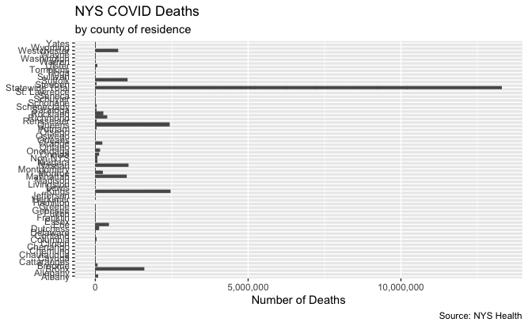

```r
ggplot(data = NYS_Covid_Deaths) +
  aes(x = county, y = deaths_by_county_of_residence) +
  geom_col() +
  coord_flip() +
   scale_y_continuous(labels = scales::comma) +
  labs(
    title = 'NYS COVID Deaths',
    subtitle = "by county of residence",
    x = NULL,
    y = "Number of Deaths",
    caption = "Source: NYS Health")
```

Final Questions: 1) Do you have the right data? I think I do 2) Do you need other data? No, I don’t think so 3) Do you have the right question? Yes, at this point I believe I do